# 3.Basic-Probability

```python
%matplotlib notebook

import numpy as np
import matplotlib.pyplot as plt
import seaborn as sns
sns.set(style="darkgrid")
# np.random.seed(19680801)
```

### Birthday Problem

In a class of N students what is the probability that atleast 2 students have same birthday => probability of 2 or more students having the same birthday => 1 - probability of no two students having the same birthday => 1 - probability of all students having different birthdays => 1 - (365/365)(364/365)...(365-N+1/365)

```python
def atleast_2_students_have_the_same_birthday(N):
    return 1 - np.prod((365 - np.arange(0,N))/365)
```

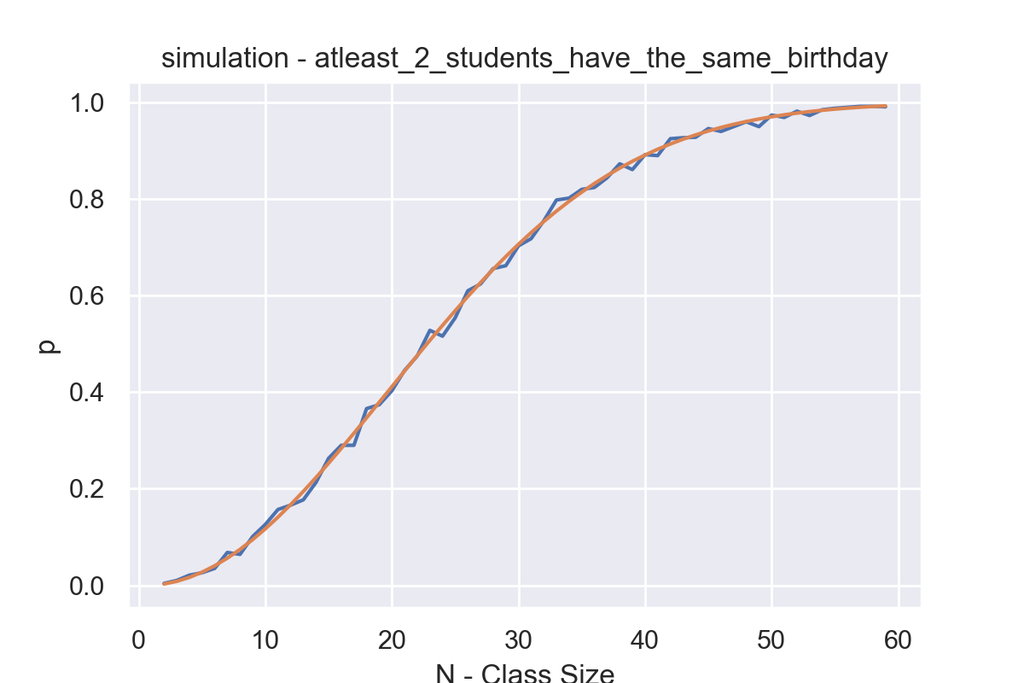

```python
def calc_p(N, p):
    birthdays = np.arange(0,365)
    students_birthdays = np.random.choice(birthdays, N) #random selection of N birthdays(with replacements)
    return p(students_birthdays) #returns if this sample has the event we are looking for - bool

def run_sim(M, N, p):
    # M - number of experiments
    # N - class size
    # p - function to decide if this sample is good
    return np.sum([calc_p(N, p) for i in range(M)])/M #Runs M experiments and return probability

def calc_birthdays_hash(students_birthdays):
    birthdays_hash = {}
    for bd in students_birthdays:
        if bd in birthdays_hash:
            birthdays_hash[bd] = birthdays_hash[bd] + 1
        else:
            birthdays_hash[bd] = 1
    return birthdays_hash

def calc_atleast_2_students_have_the_same_birthday(students_birthdays):
    birthdays_hash = calc_birthdays_hash(students_birthdays)
    occurances = 0
    for k in birthdays_hash.keys():
        if birthdays_hash[k] > 1:
            occurances = occurances + 1
    return occurances > 0

x = np.arange(2,60)
fig, ax = plt.subplots(1,1, sharex='col', sharey='row', figsize=(6,4))
ax.plot(x, [run_sim(1000, i, calc_atleast_2_students_have_the_same_birthday) for i in x], label='simulation')
ax.plot(x, [atleast_2_students_have_the_same_birthday(i) for i in x], label='theoritical')
ax.set_ylabel('p')
ax.set_xlabel('N - Class Size')
ax.set_title('simulation - atleast_2_students_have_the_same_birthday')
```

### Solution to exactly 2 students have the same birthday out of a class size N

Think of students writing their birthdays on a paper making a string Number of different strings possible = 365^N

Favorable outcomes: Any two students have the same birthday and all others don't have same birthdays

Number of ways of picking 2 students = Nc2 = N(N-1)/2  
number of ways 2 students can have the same birthday = 365 1  
number of ways all others don't have same birthdays = 364 363 ... * 365-(N-2)

p = (N(N-1)/2) *1/(365^N)* (365) *(364* 363... * 365-(N-2))

#### Solution to exactly n students have the same birthday out of a class size N

Number of different strings possible = 365^N  
Number of ways of picking n students = Ncn = N(N-1)...(N-(n-1))/(n!)  
number of ways n students can have the same birthday = 365 *1* 1 ... 1  
number of ways all others don't have same birthdays = 364 363 ... * 365-(N-n)

p = (NCn) *1/(365^N)* (365) *(364* 363... * 365-(N-n))

```python
from scipy.special import comb

def exactly_n_students_have_the_same_birthday(N, n):
    if N-n > 364:
        return 0
    return comb(N,n) *  (365/(365**n)) * np.prod((365 - np.arange(1, N-n+1))/365)
```

```python
def frequency_hash(xs):
    h = {}
    for x in xs:
        if x in h:
            h[x] = h[x] + 1
        else:
            h[x] = 1
    return h

def calc_exactly_n_students_have_the_same_birthday(n):
    def f(students_birthdays):
        birthdays_hash = frequency_hash(students_birthdays)
        same_bithday_hash = frequency_hash(birthdays_hash.values())

        if len(same_bithday_hash.keys()) == 2 and 1 in same_bithday_hash and n in same_bithday_hash and same_bithday_hash[n] == 1:
            return True
        return False
    return f
```

```python
x = np.arange(2,60)
p_exactly_2_students_have_the_same_birthday = [run_sim(1000, i, calc_exactly_n_students_have_the_same_birthday(2)) for i in x]
```

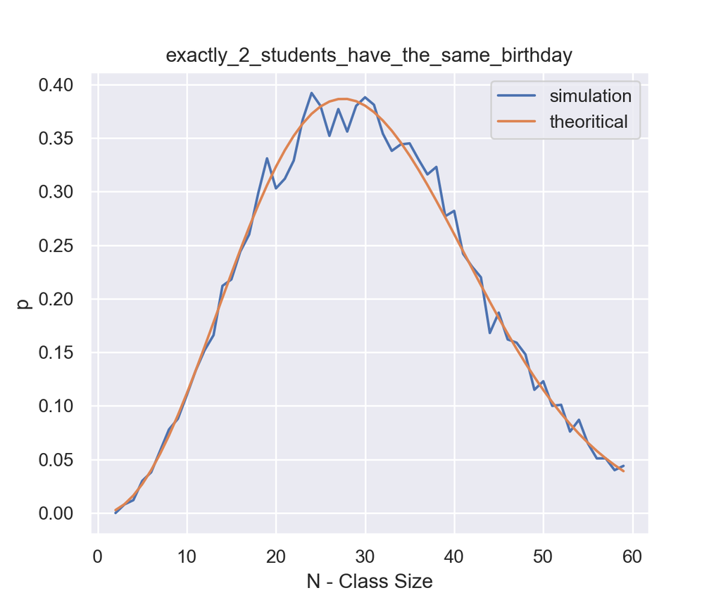

```python
x = np.arange(2,60)
fig, ax = plt.subplots(1,1, sharex='col', sharey='row', figsize=(6,5))
ax.plot(x, p_exactly_2_students_have_the_same_birthday, label='simulation')
ax.plot(x, [exactly_n_students_have_the_same_birthday(i,2) for i in x], label='theoritical')
ax.set_ylabel('p')
ax.set_xlabel('N - Class Size')
ax.set_title('exactly_2_students_have_the_same_birthday')
ax.legend()
```

```python
x = np.arange(3,200)
p_exactly_3_students_have_the_same_birthday = [run_sim(1000, i, calc_exactly_n_students_have_the_same_birthday(3)) for i in x]
```

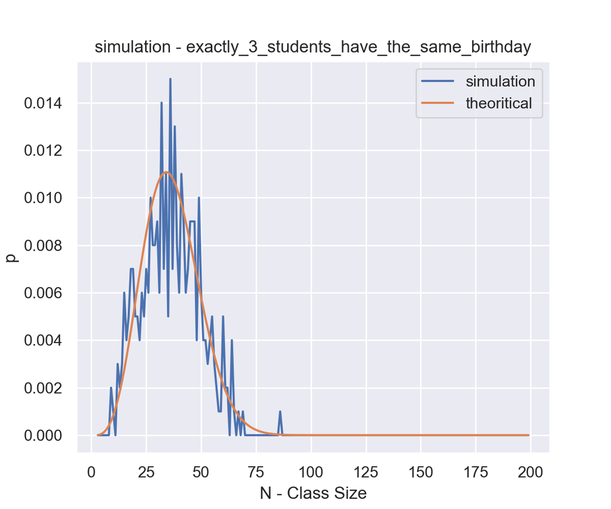

```python
x = np.arange(3,200)
fig, ax = plt.subplots(1,1, sharex='col', sharey='row', figsize=(6,5))
ax.plot(x, p_exactly_3_students_have_the_same_birthday, label='simulation')
ax.plot(x, [exactly_n_students_have_the_same_birthday(i,3) for i in x], label='theoritical')
ax.set_ylabel('p')
ax.set_xlabel('N - Class Size')
ax.set_title('simulation - exactly_3_students_have_the_same_birthday')
ax.legend()
```

```python
x = np.arange(4,100)
p_exactly_4_students_have_the_same_birthday = [run_sim(10000, i, calc_exactly_n_students_have_the_same_birthday(4)) for i in x]
```

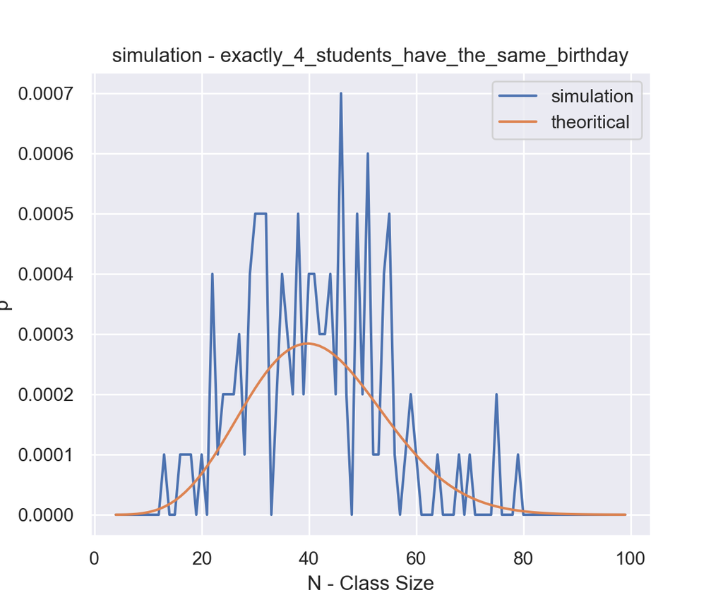

```python
x = np.arange(4,100)
fig, ax = plt.subplots(1,1, sharex='col', sharey='row', figsize=(6,5))
ax.plot(x, p_exactly_4_students_have_the_same_birthday, label='simulation')
ax.plot(x, [exactly_n_students_have_the_same_birthday(i,4) for i in x], label='theoritical')
ax.set_ylabel('p')
ax.set_xlabel('N - Class Size')
ax.set_title('simulation - exactly_4_students_have_the_same_birthday')
ax.legend()
```

### Binomial Law

An experiment has p probability to succeed. If the experiment is repeated M times (each run is independent of others) what is the probability of getting k successes?

Number of ways of choosing k places from string of length M = $\left ( {M \atop k} \right )$ probability of each arrangement of such successes and failures = $p^k(1-p)^{M-k}$

Total probability = $\left ( {M \atop k} \right )p^k(1-p)^{M-k}$

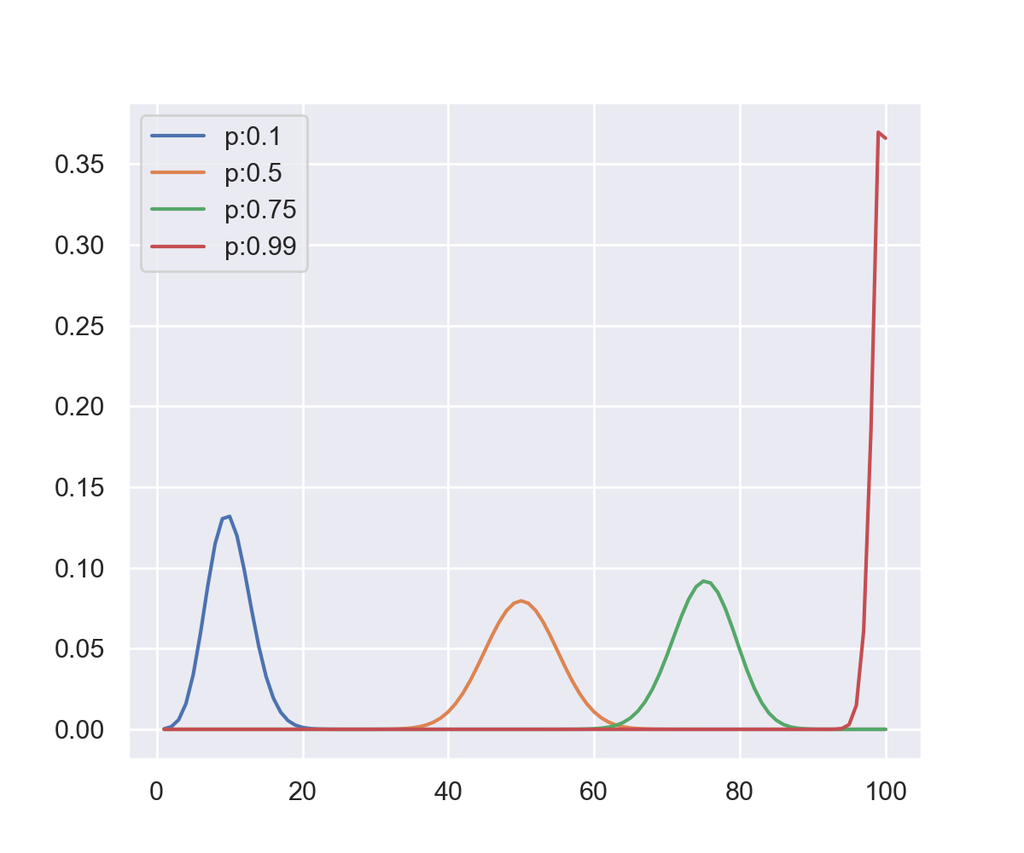

```python
def binomial_probability(M,k,p):
    return comb(M,k) * (p**k) * ((1-p)**(M-k))
fig, ax = plt.subplots(1, 1, sharex="col", sharey="row", figsize=(6,5))
M = 100
p = 0.5

k = np.arange(1,M+1)

for p in [0.1,0.5,0.75,0.99]:
    ax.plot(k, [binomial_probability(M, i, p) for i in k], label='p:%s'%(p,))

ax.legend()
ax.set_title('')
```